# RNA-seq QC

## Alignment Summary

This alignment looks quite good to me. The percent mapping is pretty consistent between samples and is quite high.

[figure not shown]

```r
# Plot alignment stats
star_stats_long_pct <- star_stats_long %>%
  filter(val_type == "pct") %>%

  # Add median rates to metric label
  mutate(
    metric = str_remove(metric, "% of reads | reads %"),
    metric = str_to_sentence(metric)
  ) %>%
  arrange(value) %>%
  mutate(metric = fct_inorder(metric))

# Plot STAR alignment stats
star_plot <- ggplot(data = star_stats_long_pct,
                    mapping = aes(x = Sample,
                                  y = value,
                                  fill = metric)) +
  geom_bar(stat = "identity", color = "white", size = 0.5) +

  # Label bars with library size
  geom_text(
    data = read_counts,
    aes(Sample, 50, label = value),
    show.legend = F,
    inherit.aes = F,
    color = "white",
    angle = 90
  ) +

  scale_fill_manual(
    values = star_colors,
    guide  = guide_legend(reverse = T)
  ) +
  scale_y_continuous(labels = function(x) {str_c(x, "%")}) +
  theme_classic() +
  theme(
    legend.title = element_blank(),
    legend.text  = element_text(size = 8, color = "black"),
    axis.title   = element_blank(),
    axis.text    = element_text(size = 8, color = "black"),
    axis.text.x  = element_text(angle = 90, hjust = 1, vjust = 0.5)
  )

star_plot
```

## Fastq screen

I also ran the alignment against many different genomes to ensure any unmapped reads could be mapped to any type of contamination. I did this using `fastq_screen`

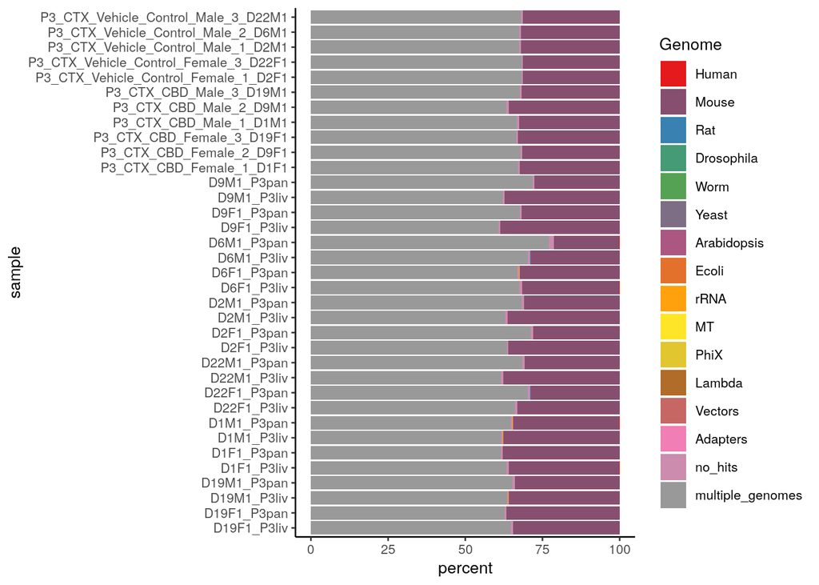

```r
# Make the plotting levels better?
fastq_screen_res$Genome <- factor(fastq_screen_res$Genome,
                                  levels = unique(fastq_screen_res$Genome))

# Pick some colors
colors <- grDevices::colorRampPalette(
  RColorBrewer::brewer.pal(name = "Set1", n = 9))(length(levels(fastq_screen_res$Genome)))

names(colors) <- levels(fastq_screen_res$Genome)

# Make a barplot
barplot <- ggplot2::ggplot(fastq_screen_res, ggplot2::aes(x = sample,
                                                          y = percent,
                                                          fill = Genome)) +
    ggplot2::geom_bar(stat = "identity", position = "stack") +
    ggplot2::coord_flip() +
    ggplot2::scale_fill_manual(values = colors)

print(barplot)
```

## PCA

Principal component analysis was performed to assess similarities between samples. Here I’ve made many plots to look at different technical effects in your data.

[figure not shown]

```r
# This makes a DESeq2 object where the count data is our count matrix and the colData is our sample data. I am currently making the design based on "group" but we can change this if necessary
sample_table$Sample_name <- factor(sample_table$Sample_name)
sample_table$genotype <- factor(sample_table$genotype)
sample_table$treatment <- factor(sample_table$treatment)
sample_table$group <- factor(sample_table$group)

dds <- DESeqDataSetFromMatrix(countData = count_table,
                              colData = sample_table,
                              design = formula(paste("~",
                                                     params$sample_column)))
# Here we get rid of all the genes that are not expressed
keep <- rowSums(counts(dds)) >= 10
dds <- dds[keep,]
dds <- DESeq(dds)

# This transforms the counts to have constant variance. This helps ensue that highly or lowly expressed genes will not contribute too much for the PCA or clustering analysis
vsd <- vst(dds, blind = F)

pc_1 <- plot_pca(vsd, group_by = "Sample_name", color_palette = sample_colors)
pc_2 <- plot_pca(vsd, group_by = "genotype", color_palette = genotype_colors)
pc_3 <- plot_pca(vsd, group_by = "treatment", color_palette = treatment_colors)
pc_4 <- plot_pca(vsd, group_by = "group", color_palette = group_colors)


plot_grid(pc_1, pc_2, pc_3, pc_4,
          labels = c("A", "B", "C", "D"),
          nrow = 2, ncol = 2,
          align = "hv",
          axis = "r",
          label_y = 1,
          label_x = 1)
```